# Project 2 Starter

## Summary

Project 2 is to facilitate students practice of the following Data Science concepts:

- Train and tune classification model
- Perform feature engineering to improve model performance
- Explain/interpret and debug model

## Tasks

The project will include following tasks:

- Load dataset. Don't use "index" column for training.
- Clean up the data:
  - Encode replace missing values
  - Replace features values that appear incorrect
  - Encode numerical variables that come as strings, for example string `$100.01` should be converted to numerical value
- Encode categorical variables
- Split dataset to Train/Test/Validation. If you perform cross-validation while tuning hyper-parameters, you don't need validation dataset.
- Add engineered features. Simple encoding (Target encoding) for individual feature doesn't count to the 10 required engineered features
- Train and tune ML models
- Provide final metrics using Test (hold-out) dataset:
  - Classification: AUC
  - Confusion matrix for best F1
- Interpret final trained model using Test dataset:
  - Global feature importance using both Shapley values and permutation feature importance
  - Summary plot with Shapley values
  - Individual observations analysis using Shapley values. Two records for each of the scenarios with significant probability:
    - Label `0` is correctly identified
    - Label `0` is identified as `1`
    - Label `1` is correctly identified
    - Label `1` is identified as `0`
    - Significant probability means high probability of being correct/in-correct (depending on the scenario)

## Datasets

You are provided with the dataset on eLearning. There were several changes made to the dataset: columns dropped/added.

The dataset is from the U.S. Small Business Administration (SBA) The U.S. SBA was founded in 1953 on the principle of promoting and assisting small enterprises in the U.S. credit market (SBA Overview and History, US Small Business Administration (2015)). Small businesses have been a primary source of job creation in the United States; therefore, fostering small business formation and growth has social benefits by creating job opportunities and reducing unemployment. There have been many success stories of start-ups receiving SBA loan guarantees such as FedEx and Apple Computer. However, there have also been stories of small businesses and/or start-ups that have defaulted on their SBA-guaranteed loans.  
More info on the original dataset: https://www.kaggle.com/mirbektoktogaraev/should-this-loan-be-approved-or-denied

**Don't use original datasets, use only dataset provided with project requirements in eLearning**

## Deliverables in a single zip file in the following structure:

- `notebook` (folder)
  - Jupyter notebook with complete code to manipulate data, train and tune final model. `ipynb` format
  - Jupyter notebook in `html` format
- `artifacts` (folder)
  - Model and any potential encoders in the "pkl" format or native H2O-3 format (for H2O-3 model)
  - Scoring function that will load the final model and encoders. Separate from above notebook or `.py` file

**Additional requirements:**

- Each cell in the notebook should have been run
- Use markdown to annotate and explain your code
- Use visualizations for ML explainability part

Your notebook should include explanations about your code and be designed to be easily followed. All results should be reproducible. Every cell with code should be run.

Once you are done with final version, you will need to test it by running all cells from top to bottom after restarting Kernel. It can be done by running `Kernel -> Restart & Run All`

**Important**: you might want to first produce working code using small subset of the dataset to speed up debugging process.

## Models

You will need to train and tune two types of models:

- GBM (H2O)
- LightGBM. To install LightGBM, run following command from your terminal after activating class virtual environment: `pip install lightgbm==3.3.5`

You will train and tune 2 models for each task for the total of 2 final models.

First, split he dataset to Train/Validation/Test, before applying any encodings clean-up or feature engineering. It is important to understand all the steps before model training, so that you can reliably replicate and test them to produce scoring function.

### Categorical variables encoding

Encode categorical variables using either one of the techniques below. Don't use LabelEncoder.

- One-hot-encoder for variables with less than 10 valid values. Name your new columns "Original_name"_valid_value
- (If using sklearn) Target encoder from the following library: https://contrib.scikit-learn.org/category_encoders/index.html . Name your new column "Original_name"_trg
- (If using H2O) Use H2O target encoder

Example of use for target encoder:

```
import category_encoders as ce

encoder = ce.TargetEncoder(cols=[...])

encoder.fit(X, y)
X_cleaned = encoder.transform(X_dirty)
```

### Feature engineering

You should train/fit categorical features encoders on Train only. Use `transform` or equivalent function on Validation/Test datasets.

It is important to understand all the steps before model training, so that you can reliably replicate and test them to produce scoring function.

You should generate various new features. Examples of such features can be seen in the Module-3 lecture on GLMs. Your final model should have at least **10** new engineered features. One-hot-encoding, label encoding, and target encoding is not included in the **10** features.

Ideas for Feature engineering for various types of variables:

1. https://docs.h2o.ai/driverless-ai/1-10-lts/docs/userguide/transformations.html
2. GLM lecture and hands-on (Module-3)

### Model Tuning

Perform hyper parameter tuning for both models.

- Hyper-parameter tuning. Your hyper-parameter search space should have at least 150 combinations or 150 Optuna trials.
- To avoid over-fitting and provide you with reasonable estimate of model performance on hold-out dataset, you will need to split your dataset as following:
  - Train, will be used to train model
  - Validation, will be used to validate model each round of training. Not needed if you perform cross-validation.
  - Testing, will be used to provide final performance metrics, used only once on the final model
- Feature engineering. You should add at least two engineered features. For example, add feature which is combination of two features.
- Calculate probability threshold to maximize F1.

It should be clearly stated what parameters were selected after hyper parameters tuning. If using early stopping, make sure final model is trained with proper parameters that include number of iterations.

To simplify scoring, train single model on provided full dataset with parameters and features found in the Tuning stage.

## Scoring Function

You only need to submit single scoring function for either GBM or LightGBM model. The scoring function will perform the following activities:

- Accept dataset in the same format as provided with the project, minus "target" column
- Load trained model and any encoders that are needed to transform data
- Transform dataset into format that can be scored with the trained model
- Score the dataset and return the results, for each record in a similar way as in Project 1:
  - Record label as determined by final model
  - You need to assign label based on maximum F1 threshold
  - Probability

```
index	label	probability_0	probability_1
1	      0	        0.901298	0.098702
2	      1	        0.071879	0.928121
3	      1	        0.367665	0.632335
4	      1	        0.098564	0.901436
5	      0	        0.923460	0.076540
```

See Project 1 for more details on scoring function and working example.

### Threshold calculation

You will need to calculate optimal threshold for class assignment using F1 metric:

- If using sklearn, use F1 `macro`: `f1_score(y_true, y_pred, average='macro')`
- If using H2O-3, use F1

You will need to find optimal probability threshold for class assignment, the threshold that maximizes above F1.

### Model interpretation

You should provide detailed write-up on what features are important for the model predictions. Your write-up should be written in "english" and in the way business manager can understand how the model works. At the minimum include:

- Shapley summary graph: `shap.plots.beeswarm`
- Shapley feature interaction graphs: `shap.plots.scatter`
- Multiple examples of single records Shapley graphs with explanations.
- Strong/Weak points of the model
- Are there any scenarios (particular input data) that will require over-write model prediction?

Resources: https://github.com/slundberg/shap

### Model performance in H2O Driverless AI (performance to aim for)

I run experiments in DAI without any data manipulation. It means that potential improvement in performance can be gained after data is cleaned. AUC on cross-validation dataset: 0.8515 AUC on hold-out (not provided, will be evaluated on during grading): 0.855

Three top features:

- CVTE:Bank:BankState:FranchiseCode:SBA_Appv.0
- CVTE:Bank:BankState:NAICS:UrbanRural.0
- WoE:Bank:BankState:NAICS.0

CVTE: cross-validated target encoding WoE : weight of evidence

## Save all artifacts

Save all artifacts needed for scoring function:

- Trained model
- Encoders

You should restart your Kernel to properly test scoring function

## Model Scoring

Use example scoring function from Project 1 as the reference.

```python
# !pip install lightgbm==3.3.5
```

### 1. Load dataset

```python
import pandas as pd
import numpy as np

data = pd.read_csv("./data/SBA_loans_project_2.zip")
```

```python
df = data.drop(columns = ['index'])
```

```python
df.columns
```

```
Index(['City', 'State', 'Zip', 'Bank', 'BankState', 'NAICS', 'NoEmp',
       'NewExist', 'CreateJob', 'RetainedJob', 'FranchiseCode', 'UrbanRural',
       'RevLineCr', 'LowDoc', 'DisbursementGross', 'BalanceGross', 'GrAppv',
       'SBA_Appv', 'LoanInd', 'MIS_Status'],
      dtype='object')
```

### 2. Clean up the data:

```python
df.isna().sum()
```

```
City                   26
State                  13
Zip                     0
Bank                 1347
BankState            1353
NAICS                   0
NoEmp                   0
NewExist              122
CreateJob               0
RetainedJob             0
FranchiseCode           0
UrbanRural              0
RevLineCr            4090
LowDoc               2291
DisbursementGross       0
BalanceGross            0
GrAppv                  0
SBA_Appv                0
LoanInd                 0
MIS_Status              0
dtype: int64
```

### Remove irrelevant features

```python
# df = df.drop(columns=['City','State','Zip','Bank','BankState','FranchiseCode'])
```

### drop missing

```python
# Because the amount of missing value is so small comparing to the total amount of data.
# The row with missing value will be dropped.
df=df.dropna()
```

```python
# Recheck the missing value
df.isnull().sum()
```

```
City                 0
State                0
Zip                  0
Bank                 0
BankState            0
NAICS                0
NoEmp                0
NewExist             0
CreateJob            0
RetainedJob          0
FranchiseCode        0
UrbanRural           0
RevLineCr            0
LowDoc               0
DisbursementGross    0
BalanceGross         0
GrAppv               0
SBA_Appv             0
LoanInd              0
MIS_Status           0
dtype: int64
```

```python
# Show the data types
df.dtypes
```

```
City                  object
State                 object
Zip                    int64
Bank                  object
BankState             object
NAICS                  int64
NoEmp                  int64
NewExist             float64
CreateJob              int64
RetainedJob            int64
FranchiseCode          int64
UrbanRural             int64
RevLineCr             object
LowDoc                object
DisbursementGross     object
BalanceGross          object
GrAppv                object
SBA_Appv              object
LoanInd                int64
MIS_Status             int64
dtype: object
```

```python
# convert data types
df = df.convert_dtypes()
```

```python
df.dtypes
```

```
City                 string
State                string
Zip                   Int64
Bank                 string
BankState            string
NAICS                 Int64
NoEmp                 Int64
NewExist              Int64
CreateJob             Int64
RetainedJob           Int64
FranchiseCode         Int64
UrbanRural            Int64
RevLineCr            string
LowDoc               string
DisbursementGross    string
BalanceGross         string
GrAppv               string
SBA_Appv             string
LoanInd               Int64
MIS_Status            Int64
dtype: object
```

### Clean money columns

```python
# convert '$XXXX.XX' strings to float values
money_cols = ['DisbursementGross', 'BalanceGross', 'GrAppv', 'SBA_Appv']
df[money_cols] = df[money_cols].applymap(lambda x: x.strip().replace('$', '').replace(',', ''))
df[money_cols] = df[money_cols].astype('float64')
df[money_cols] = df[money_cols].astype('int64')
```

### Clean the targte column

```python
df.MIS_Status.value_counts()
```

```
0    658827
1    140741
Name: MIS_Status, dtype: Int64
```

### Clean RevLineCr column

```python
# Show the unique value of RevLineCr
df['RevLineCr'].value_counts()
```

```
N    374530
0    231623
Y    179685
T     13673
1        19
R        13
`        10
2         5
Q         1
5         1
C         1
-         1
7         1
.         1
A         1
4         1
,         1
3         1
Name: RevLineCr, dtype: Int64
```

```python
# as we know that unique value of RevLineCr column is only Y and N, so we have to remove another unique value.

values = ['0','T','1','R','`','2','C','3',',','7','A','5','.','4','-','Q']
df = df[df.RevLineCr.isin(values) == False]
```

### Clean LowDoc column

```python
# Show the unique value of LowDoc
df['LowDoc'].value_counts()
```

```
N    500376
Y     51539
0      1023
C       625
S       510
A        92
R        49
1         1
Name: LowDoc, dtype: Int64
```

```python
# as we it is known that unique value of RevLineCr column is only Y and N, so we have to remove another unique value.

values = ['0','C','S','A','R','1']
df = df[df.LowDoc.isin(values) == False]
```

### Encoding Categorical variables (Changing the category names of NAICS)

```python
df['NAICS'] = df['NAICS'].astype('str').apply(lambda x: x[:2])
df['NAICS'] = df['NAICS'].map({
    '11': 'Ag_For_Fish_Hunt',
    '21': 'Min_Quar_Oil_Gas_ext',
    '22': 'Utilities',
    '23': 'Construction',
    '31': 'Manufacturing',
    '32': 'Manufacturing',
    '33': 'Manufacturing',
    '42': 'Wholesale_trade',
    '44': 'Retail_trade',
    '45': 'Retail_trade',
    '48': 'Trans_Ware',
    '49': 'Trans_Ware',
    '51': 'Information',
    '52': 'Finance_Insurance',
    '53': 'RE_Rental_Lease',
    '54': 'Prof_Science_Tech',
    '55': 'Mgmt_comp',
    '56': 'Admin_sup_Waste_Mgmt_Rem',
    '61': 'Educational',
    '62': 'Healthcare_Social_assist',
    '71': 'Arts_Entertain_Rec',
    '72': 'Accom_Food_serv',
    '81': 'Other_no_pub',
    '92': 'Public_Admin'
})
df = df.dropna(subset=['NAICS'])
```

### Feature engineerng

#### Loan Approval Ratio:

This feature could be calculated as the ratio of the SBA_Appv (the amount of money guaranteed by the Small Business Administration) to the GrAppv (the amount of money approved for the loan). This feature would indicate how much of the loan was guaranteed by the SBA compared to the total loan amount approved by the bank. A higher ratio could indicate a lower risk of default, as the loan has a larger government guarantee. On the other hand, a lower ratio could indicate a higher risk of default, as the loan has a smaller government guarantee.

```python
df['Loan_Approval_Ratio'] = df['SBA_Appv'] / df['GrAppv']
```

#### Loan to Disbursement Ratio:

This feature could be calculated as the ratio of the DisbursementGross (the amount of money disbursed to the business) to the GrAppv (the amount of money approved for the loan). This feature would indicate how much of the approved loan amount was actually disbursed to the business. A higher ratio could indicate that the business is more likely to use the full loan amount to support their operations, which could suggest that they have a solid plan for how to use the funds to generate revenue and repay the loan. On the other hand, a lower ratio could indicate that the business is less likely to use the full loan amount, which could suggest that they are taking on less risk with the loan and may have less potential for growth and revenue generation.

```python
df['Loan_Disbursement_Ratio'] = df['DisbursementGross'] / df['GrAppv']
```

#### log transformations

It can reduce the influence of extreme values and outliers in the data, which can have a disproportionate impact on statistical measures like the mean and standard deviation.

```python
df['Log_DisbursementGross'] = np.log(df['DisbursementGross'])
```

```python
df.columns
```

```
Index(['City', 'State', 'Zip', 'Bank', 'BankState', 'NAICS', 'NoEmp',
       'NewExist', 'CreateJob', 'RetainedJob', 'FranchiseCode', 'UrbanRural',
       'RevLineCr', 'LowDoc', 'DisbursementGross', 'BalanceGross', 'GrAppv',
       'SBA_Appv', 'LoanInd', 'MIS_Status', 'Loan_Approval_Ratio',
       'Loan_Disbursement_Ratio', 'Log_DisbursementGross'],
      dtype='object')
```

```python
numerical_columns = [
'NoEmp',
'CreateJob',
'RetainedJob',
'DisbursementGross',
'BalanceGross',
'GrAppv',
'SBA_Appv',
'LoanInd',
'Loan_Approval_Ratio',
'Loan_Disbursement_Ratio',
'Log_DisbursementGross'
]

categorical_columns = [
'City',
'State',
'Zip',
'Bank',
'BankState',
'FranchiseCode',
'NAICS',
'NewExist',
'UrbanRural',
'RevLineCr',
'LowDoc']

target_column = 'MIS_Status'
```

```python
df
```

|  | City | State | Zip | Bank | BankState | NAICS | NoEmp | NewExist | CreateJob | RetainedJob | ... | LowDoc | DisbursementGross | BalanceGross | GrAppv | SBA_Appv | LoanInd | MIS_Status | Loan_Approval_Ratio | Loan_Disbursement_Ratio | Log_DisbursementGross |
| --- | --- | --- | --- | --- | --- | --- | --- | --- | --- | --- | --- | --- | --- | --- | --- | --- | --- | --- | --- | --- | --- |
| 0 | PRINCETON | MN | 55371 | PEOPLES BANK OF COMMERCE | MN | Retail_trade | 4 | 2 | 0 | 0 | ... | N | 114577 | 0 | 114577 | 85933 | 1 | 0 | 0.750002 | 1.000000 | 11.649002 |
| 1 | Kansas city | MO | 64116 | BANK OF HAYS | KS | Trans_Ware | 14 | 1 | 0 | 14 | ... | N | 25000 | 0 | 25000 | 12500 | 7 | 0 | 0.500000 | 1.000000 | 10.126631 |
| 4 | EL PASO | TX | 79925 | WESTSTAR BANK | TX | Wholesale_trade | 4 | 1 | 0 | 4 | ... | N | 32000 | 0 | 32000 | 16000 | 9 | 0 | 0.500000 | 1.000000 | 10.373491 |
| 5 | NASHUA | IA | 50658 | FIRST NATIONAL BANK | IA | Prof_Science_Tech | 9 | 1 | 0 | 0 | ... | N | 150000 | 0 | 150000 | 112500 | 7 | 0 | 0.750000 | 1.000000 | 11.918391 |
| 6 | DOVER | DE | 19904 | WILMINGTON SAVINGS FUND SOCIET | DE | Construction | 3 | 2 | 1 | 2 | ... | N | 90317 | 0 | 35000 | 17500 | 7 | 0 | 0.500000 | 2.580486 | 11.411081 |
| ... | ... | ... | ... | ... | ... | ... | ... | ... | ... | ... | ... | ... | ... | ... | ... | ... | ... | ... | ... | ... | ... |
| 807438 | TERRE HAUTE | IN | 47802 | FIRST FINAN BANK NATL ASSOC | IN | Retail_trade | 2 | 1 | 0 | 0 | ... | N | 163700 | 0 | 163700 | 103131 | 5 | 0 | 0.630000 | 1.000000 | 12.005791 |
| 807439 | CHICAGO | IL | 60602 | NORTH COMMUNITY BANK | IL | Prof_Science_Tech | 4 | 1 | 0 | 0 | ... | Y | 25000 | 0 | 25000 | 22500 | 7 | 0 | 0.900000 | 1.000000 | 10.126631 |
| 807440 | NEW HOPE | MN | 55422 | STATE BANK OF DELANO | MN | Other_no_pub | 1 | 1 | 0 | 0 | ... | Y | 91000 | 0 | 91000 | 81900 | 10 | 0 | 0.900000 | 1.000000 | 11.418615 |
| 807446 | ARLINGTON | TX | 76016 | JPMORGAN CHASE BANK NATL ASSOC | IL | Admin_sup_Waste_Mgmt_Rem | 1 | 1 | 0 | 1 | ... | N | 129886 | 0 | 40300 | 20150 | 1 | 0 | 0.500000 | 3.222978 | 11.774412 |
| 807448 | MERIDEN | CT | 6451 | ION BANK | CT | Admin_sup_Waste_Mgmt_Rem | 80 | 1 | 0 | 80 | ... | N | 196500 | 0 | 80000 | 40000 | 6 | 0 | 0.500000 | 2.456250 | 12.188418 |

413464 rows × 23 columns

```python
def cleaning(df,train=True):
    try:
        df = df.drop(columns=['index'],axis=1)
    except:
        pass

    # drop null
    df = df.dropna()

    # clean money columns
    money_cols = ['DisbursementGross', 'BalanceGross', 'GrAppv', 'SBA_Appv']
    df[money_cols] = df[money_cols].applymap(lambda x: x.strip().replace('$', '').replace(',', ''))
    df[money_cols] = df[money_cols].astype('float64')
    df[money_cols] = df[money_cols].astype('int64')

    # clean MIS_Status
#     df['MIS_Status'] = df['MIS_Status'].apply(lambda x: 1 if x == "CHGOFF" else 0)

    # clean RevLineCr
    values = ['0','T','1','R','`','2','C','3',',','7','A','5','.','4','-','Q']
    df = df[df.RevLineCr.isin(values) == False]

    # clean LowDoc
    values = ['0','C','S','A','R','1']
    df = df[df.LowDoc.isin(values) == False]

    # clean NAICS
    df['NAICS'] = df['NAICS'].astype('str').apply(lambda x: x[:2])
    df['NAICS'] = df['NAICS'].map({
        '11': 'Ag_For_Fish_Hunt',
        '21': 'Min_Quar_Oil_Gas_ext',
        '22': 'Utilities',
        '23': 'Construction',
        '31': 'Manufacturing',
        '32': 'Manufacturing',
        '33': 'Manufacturing',
        '42': 'Wholesale_trade',
        '44': 'Retail_trade',
        '45': 'Retail_trade',
        '48': 'Trans_Ware',
        '49': 'Trans_Ware',
        '51': 'Information',
        '52': 'Finance_Insurance',
        '53': 'RE_Rental_Lease',
        '54': 'Prof_Science_Tech',
        '55': 'Mgmt_comp',
        '56': 'Admin_sup_Waste_Mgmt_Rem',
        '61': 'Educational',
        '62': 'Healthcare_Social_assist',
        '71': 'Arts_Entertain_Rec',
        '72': 'Accom_Food_serv',
        '81': 'Other_no_pub',
        '92': 'Public_Admin'
    })
    df = df.dropna(subset=['NAICS'])

    df['Loan_Approval_Ratio'] = df['SBA_Appv'] / df['GrAppv']
    df['Loan_Disbursement_Ratio'] = df['DisbursementGross'] / df['GrAppv']
    df['Log_DisbursementGross'] = np.log(df['DisbursementGross'])

    numerical_columns = [
    # 'Term',
    'NoEmp',
    'CreateJob',
    'RetainedJob',
    'DisbursementGross',
    'BalanceGross',
    'GrAppv',
    'SBA_Appv',
    'LoanInd',
    'Loan_Approval_Ratio',
    'Loan_Disbursement_Ratio',
    'Log_DisbursementGross']

    categorical_columns = [
    'City',
    'State',
    'Zip',
    'Bank',
    'BankState',
    'FranchiseCode',
    'NAICS',
    'NewExist',
    'UrbanRural',
    'RevLineCr',
    'LowDoc']

    target_column = 'MIS_Status'

    X = df[categorical_columns+numerical_columns]
    y = df[target_column]

    data = (X,y)
    features = (categorical_columns,numerical_columns,target_column)

    return (data, features)
```

### 3. Split dataset to Train/Test/Validation. If you perform cross-validation while tuning hyper-parameters, you don't need validation dataset.

```python
X,y = cleaning(data)[0]
categorical_columns,numerical_columns,target_column = cleaning(data)[1]
```

```python
X = data.iloc[:,:-1]
y = data.iloc[:,-1]
```

```python
from sklearn.model_selection import train_test_split

# Split data into train and test sets
X_train_full, X_test, y_train_full, y_test = train_test_split(X, y, test_size=0.2,random_state=42, stratify=y)

# Split train data into train and validation sets using train_test_split
X_train, X_val, y_train, y_val = train_test_split(X_train_full, y_train_full, test_size=0.2, random_state=42, stratify=y_train_full)
```

```python
train_data = X_train_full.copy()
train_data.loc[:,target_column] = y_train
train_data.to_csv('train_data.csv',index=False)
```

```python
test_data = X_val.copy()
test_data.loc[:,target_column] = y_val
test_data.to_csv('val_data.csv',index=False)
```

```python
test_data = X_test.copy()
test_data.loc[:,target_column] = y_test
test_data.to_csv('test_data.csv',index=False)
```

### Load the saved data

```python
import pandas as pd
import numpy as np
```

```python
train_data = pd.read_csv('train_data.csv')
val_data = pd.read_csv('val_data.csv')
test_data = pd.read_csv('test_data.csv')
```

```python
X_train,y_train = cleaning(train_data)[0]
categorical_columns,numerical_columns,target_column = cleaning(train_data)[1]
```

```python
X_val,y_val = cleaning(val_data)[0]
X_test,y_test = cleaning(test_data)[0]
```

```python
X_train.shape,X_val.shape,X_test.shape
```

```
((264675, 22), (66265, 22), (82524, 22))
```

### 4. Encode categorical variables

```python
categories_less_than_10 = []
categories_more_than_10 = []
for c in list(train_data[categorical_columns]):
    size = len(train_data[c].unique())
    print(f'No of Unique Categories in {c} : {size} | {train_data[c].dtype}')
    if size <= 10:
        categories_less_than_10.append(c)
    else:
        categories_more_than_10.append(c)
poly_numerical_features = [
    'DisbursementGross',
    'BalanceGross',
    'GrAppv',
    'SBA_Appv']
```

```
No of Unique Categories in City : 28715 | object
No of Unique Categories in State : 52 | object
No of Unique Categories in Zip : 30965 | int64
No of Unique Categories in Bank : 5527 | object
No of Unique Categories in BankState : 57 | object
No of Unique Categories in FranchiseCode : 2497 | int64
No of Unique Categories in NAICS : 1303 | int64
No of Unique Categories in NewExist : 4 | float64
No of Unique Categories in UrbanRural : 3 | int64
No of Unique Categories in RevLineCr : 15 | object
No of Unique Categories in LowDoc : 9 | object
```

```python
from category_encoders import WOEEncoder, OneHotEncoder
from sklearn.preprocessing import StandardScaler
from sklearn.preprocessing import PolynomialFeatures
```

```python
one_hot_encoder = OneHotEncoder(cols=categories_less_than_10)
woe_encoder = WOEEncoder(cols=categories_more_than_10)
standard_scaler = StandardScaler()
poly = PolynomialFeatures(degree=3, include_bias=False, interaction_only=True)

X_train_encoded = one_hot_encoder.fit_transform(X_train,y_train)
X_train_encoded = woe_encoder.fit_transform(X_train_encoded,y_train)
X_train_encoded[numerical_columns] = standard_scaler.fit_transform(X_train_encoded[numerical_columns])

poly_df = poly.fit_transform(X_train_encoded[poly_numerical_features])[:,len(poly_numerical_features):]
poly_features = poly.get_feature_names_out(input_features=poly_numerical_features)[len(poly_numerical_features):]
X_train_encoded[poly_features] = poly_df

X_train_encoded[target_column] = y_train

X_train_encoded.to_csv('X_train_encoded.csv',index=False)
```

```python
X_val_encoded = one_hot_encoder.transform(X_val,y_val)
X_val_encoded = woe_encoder.transform(X_val_encoded,y_val)
X_val_encoded[numerical_columns] = standard_scaler.transform(X_val_encoded[numerical_columns])

poly_df= poly.fit_transform(X_val_encoded[poly_numerical_features])[:,len(poly_numerical_features):]
poly_features = poly.get_feature_names_out(input_features=poly_numerical_features)[len(poly_numerical_features):]
X_val_encoded[poly_features] = poly_df

X_val_encoded[target_column] = y_val

X_val_encoded.to_csv('X_val_encoded.csv',index=False)
```

```python
X_test_encoded = one_hot_encoder.transform(X_test,y_test)
X_test_encoded = woe_encoder.transform(X_test_encoded,y_test)
X_test_encoded[numerical_columns] = standard_scaler.transform(X_test_encoded[numerical_columns])

poly_df= poly.fit_transform(X_test_encoded[poly_numerical_features])[:,len(poly_numerical_features):]
poly_features = poly.get_feature_names_out(input_features=poly_numerical_features)[len(poly_numerical_features):]
X_test_encoded[poly_features] = poly_df

X_test_encoded[target_column] = y_test

X_test_encoded.to_csv('X_test_encoded.csv',index=False)
```

```python
X_train_encoded.shape,X_val_encoded.shape,X_test_encoded.shape
```

```
((264675, 38), (66265, 38), (82524, 38))
```

### 6. Train and tune ML models

```python
X_train_encoded.MIS_Status.value_counts()
```

```
0.0    207903
1.0     56772
Name: MIS_Status, dtype: int64
```

```python
X_train_encoded = pd.read_csv('X_train_encoded.csv')
X_val_encoded = pd.read_csv('X_val_encoded.csv')
```

```python
X_train = X_train_encoded.drop(columns = 'MIS_Status',axis=1)
y_train = X_train_encoded['MIS_Status']
```

```python
X_val = X_val_encoded.drop(columns = 'MIS_Status',axis=1)
y_val = X_val_encoded['MIS_Status']
```

```python
import lightgbm as lgb
import xgboost as xgb
from sklearn.metrics import f1_score,accuracy_score,auc,roc_auc_score
from sklearn.model_selection import GridSearchCV
from tqdm import tqdm
import numpy as np
```

### Light GBM

```python
model = lgb.LGBMClassifier(
    learning_rate=0.1,
    n_estimators=100,
    objective='binary',
    random_state=42
)
```

```python
model.fit(X_train, y_train)
```

```
LGBMClassifier(objective='binary', random_state=42)
```

```python
y_pred_proba = model.predict_proba(X_val)
auc = roc_auc_score(y_val, y_pred_proba[:, 1])
print("AUC Score: %.2f%%" % (auc * 100.0))
```

```
AUC Score: 81.57%
```

```python
import warnings
warnings.filterwarnings('ignore')
```

```python
param_grid = {
    'learning_rate': [0.01, 0.05, 0.1, 0.15, 0.5],
    'n_estimators': [100, 200, 300, 400, 500],
    'num_leaves': [10, 20, 30, 40, 50]
}

model = lgb.LGBMClassifier(objective='binary', random_state=42)

grid_search = GridSearchCV(estimator=model, param_grid=param_grid, cv=5)

fit_params = {
    'eval_set': [(X_val, y_val)],
    'early_stopping_rounds': 10,
    'verbose': False
}

grid_search.fit(X_train, y_train, **fit_params)


print("Best Parameters",grid_search.best_params_)
print("Best AUC",grid_search.best_score_)
```

[output not shown]

### H2O

```python
import h2o
try:
    h2o.cluster().shutdown()
except:
    pass
h2o.init()
```

[output not shown]

| H2O_cluster_uptime: | 01 secs |
| --- | --- |
| H2O_cluster_timezone: | America/Chicago |
| H2O_data_parsing_timezone: | UTC |
| H2O_cluster_version: | 3.38.0.4 |
| H2O_cluster_version_age: | 4 months and 1 day !!! |
| H2O_cluster_name: | H2O_from_python_16826_m9jzd0 |
| H2O_cluster_total_nodes: | 1 |
| H2O_cluster_free_memory: | 3.934 Gb |
| H2O_cluster_total_cores: | 8 |
| H2O_cluster_allowed_cores: | 8 |
| H2O_cluster_status: | locked, healthy |
| H2O_connection_url: | http://127.0.0.1:54321 |
| H2O_connection_proxy: | {"http": null, "https": null} |
| H2O_internal_security: | False |
| Python_version: | 3.8.10 final |

```python
train = h2o.import_file('X_train_encoded.csv')
val = h2o.import_file('X_val_encoded.csv')
test = h2o.import_file('X_test_encoded.csv')
```

```
Parse progress: |████████████████████████████████████████████████████████████████| (done) 100%
Parse progress: |████████████████████████████████████████████████████████████████| (done) 100%
Parse progress: |████████████████████████████████████████████████████████████████| (done) 100%
```

```python
features = train.col_names
response = 'MIS_Status'
features.remove(response)
cat_columns = []
train[cat_columns+[response]] = train[cat_columns+[response]].asfactor()
val[cat_columns+[response]] = val[cat_columns+[response]].asfactor()
test[cat_columns+[response]] = test[cat_columns+[response]].asfactor()
```

#### H2O on encoded data

```python
from h2o.estimators import H2OGradientBoostingEstimator
from h2o.grid.grid_search import H2OGridSearch
```

```python
model_params = {
    'nfolds': 5,
    'ntrees': 500,
    'stopping_rounds': 5,
    'stopping_metric': 'AUCPR',
    'seed': 1234,
    'keep_cross_validation_predictions': False
}



gbm_model = H2OGradientBoostingEstimator(**model_params)
gbm_model.train(x=features, y=response, training_frame=train, validation_frame=val)

perf = gbm_model.model_performance(test_data=test)
```

```
gbm Model Build progress: |██████████████████████████████████████████████████████| (done) 100%
```

```python
print("AUC on test dataset: ", perf.auc())
```

```
AUC on test dataset:  0.8190229665989628
```

### Tune H2o

```python
gbm_params = {
                'learn_rate': [0.1,0.3,0.5],
                'max_depth': [ 5,7,9],
                'sample_rate': [0.8, 1.0],
                 'ntrees': [1000,1200,1500]}
gbm = H2OGradientBoostingEstimator(seed=123)


grid = H2OGridSearch(model=gbm, grid_id='gbm_grid1',hyper_params=gbm_params)
grid.train(x=features, y=response, training_frame=train, validation_frame=val,stopping_rounds=10, stopping_tolerance=1e-3, seed=1)
```

```
gbm Grid Build progress: |███████████████████████████████████████████████████████| (done) 100%
```

Hyper-Parameter Search Summary: ordered by increasing logloss

|  | learn_rate | max_depth | ntrees | sample_rate | model_ids | logloss |
| --- | --- | --- | --- | --- | --- | --- |
|  | 0.1 | 9.0 | 1000.0 | 1.0 | gbm_grid1_model_34 | 0.4018943 |
|  | 0.1 | 9.0 | 1200.0 | 1.0 | gbm_grid1_model_43 | 0.4018943 |
|  | 0.1 | 9.0 | 1500.0 | 1.0 | gbm_grid1_model_52 | 0.4018943 |
|  | 0.1 | 9.0 | 1200.0 | 0.8 | gbm_grid1_model_16 | 0.4022400 |
|  | 0.1 | 9.0 | 1500.0 | 0.8 | gbm_grid1_model_25 | 0.4022400 |
|  | 0.1 | 9.0 | 1000.0 | 0.8 | gbm_grid1_model_7 | 0.4022400 |
|  | 0.1 | 7.0 | 1200.0 | 0.8 | gbm_grid1_model_13 | 0.4024424 |
|  | 0.1 | 7.0 | 1500.0 | 0.8 | gbm_grid1_model_22 | 0.4024424 |
|  | 0.1 | 7.0 | 1000.0 | 0.8 | gbm_grid1_model_4 | 0.4024424 |
|  | 0.1 | 7.0 | 1000.0 | 1.0 | gbm_grid1_model_31 | 0.4025505 |
| --- | --- | --- | --- | --- | --- | --- |
|  | 0.5 | 7.0 | 1500.0 | 1.0 | gbm_grid1_model_51 | 0.4102017 |
|  | 0.5 | 7.0 | 1200.0 | 0.8 | gbm_grid1_model_15 | 0.4130105 |
|  | 0.5 | 7.0 | 1500.0 | 0.8 | gbm_grid1_model_24 | 0.4130105 |
|  | 0.5 | 7.0 | 1000.0 | 0.8 | gbm_grid1_model_6 | 0.4130105 |
|  | 0.5 | 9.0 | 1000.0 | 1.0 | gbm_grid1_model_36 | 0.4183714 |
|  | 0.5 | 9.0 | 1200.0 | 1.0 | gbm_grid1_model_45 | 0.4183714 |
|  | 0.5 | 9.0 | 1500.0 | 1.0 | gbm_grid1_model_54 | 0.4183714 |
|  | 0.5 | 9.0 | 1200.0 | 0.8 | gbm_grid1_model_18 | 0.4222048 |
|  | 0.5 | 9.0 | 1500.0 | 0.8 | gbm_grid1_model_27 | 0.4222048 |
|  | 0.5 | 9.0 | 1000.0 | 0.8 | gbm_grid1_model_9 | 0.4222048 |

```
[54 rows x 7 columns]
```

```python
gbm_grid = grid.get_grid(sort_by='auc', decreasing=True)
```

```python
best_gbm = gbm_grid.models[0]
```

```python
best_gbm.auc(test)
```

```
0.8979685852328444
```

```python
h2o.save_grid(grid_directory='./h2o_model_grids',grid_id='gbm_grid1')
```

```
'./h2o_model_grids/gbm_grid1'
```

### 7. Provide final metrics using Test (hold-out) dataset:

#### 7.1 Classification: AUC

```python
print("AUC on test dataset: ", round(best_gbm.auc(test)*100,2))
```

```
AUC on test dataset:  89.8
```

```python
print("F1 on test dataset: ", round(best_gbm.F1()[0][1]*100),2)
```

[output not shown]

```python
best_threshold = best_gbm.find_threshold_by_max_metric(metric='F1')
print("Threshold for Best F1: ",round(best_threshold,2))
```

```
Threshold for Best F1:  0.32
```

```python
best_gbm.confusion_matrix()
```

Confusion Matrix (Act/Pred) for max f1 @ threshold = 0.32176474112320114

|  | 0 | 1 | Error | Rate |
| --- | --- | --- | --- | --- |
| 0 | 183205.0 | 24698.0 | 0.1188 | (24698.0/207903.0) |
| 1 | 15943.0 | 40829.0 | 0.2808 | (15943.0/56772.0) |
| Total | 199148.0 | 65527.0 | 0.1536 | (40641.0/264675.0) |

## Save all artifacts

Save all artifacts needed for scoring function:

- Trained model
- Encoders
- Any other arficats you will need for scoring

```python
import pickle
#import os
#artifacts_folder=os.makedirs("artifacts", exist_ok="True")
artifacts_dict = {
        "ohe_encoder": one_hot_encoder,
        "woe_encoder": woe_encoder,
        "numerical_encoder": standard_scaler,
        "poly_features_encoder" : poly,
        "poly_numerical_features" :poly_numerical_features,
        "ohe_columns": categories_less_than_10,
        "woe_columns" : categories_more_than_10,
        "numerical_columns" : numerical_columns,
        "target_column" : "MIS_Status",
    }
artifacts_dict_file = open("./artifacts_dict_file.pkl", "wb")
pickle.dump(obj=artifacts_dict, file=artifacts_dict_file)

artifacts_dict_file.close()
```

### 8. Interpret final trained model using Test dataset:

```python
grid = h2o.load_grid('./h2o_model_grids/gbm_grid1')
best_gbm= gbm_grid.models[0]
```

#### 8.1 Global feature importance using both Shapley values and permutation feature importance

```python
perm_imp = best_gbm.permutation_importance(frame=test,use_pandas=True, metric="PR_AUC")
perm_imp
```

| Variable | Relative Importance | Scaled Importance | Percentage |
| --- | --- | --- | --- |
| Bank | 0.164827 | 1.000000 | 0.286912 |
| Zip | 0.071665 | 0.434787 | 0.124746 |
| Loan_Disbursement_Ratio | 0.059080 | 0.358439 | 0.102841 |
| RevLineCr | 0.058585 | 0.355436 | 0.101979 |
| BankState | 0.051079 | 0.309892 | 0.088912 |
| FranchiseCode | 0.050626 | 0.307148 | 0.088124 |
| City | 0.015966 | 0.096864 | 0.027791 |
| Log_DisbursementGross | 0.014619 | 0.088694 | 0.025448 |
| NAICS | 0.013928 | 0.084501 | 0.024244 |
| UrbanRural_1 | 0.013369 | 0.081108 | 0.023271 |
| SBA_Appv | 0.011599 | 0.070372 | 0.020191 |
| Loan_Approval_Ratio | 0.010338 | 0.062722 | 0.017996 |
| State | 0.007895 | 0.047897 | 0.013742 |
| GrAppv | 0.005483 | 0.033267 | 0.009545 |
| RetainedJob | 0.004655 | 0.028243 | 0.008103 |
| NewExist_1 | 0.003635 | 0.022052 | 0.006327 |
| NoEmp | 0.003296 | 0.019995 | 0.005737 |
| GrAppv SBA_Appv | 0.002317 | 0.014057 | 0.004033 |
| CreateJob | 0.002015 | 0.012227 | 0.003508 |
| NewExist_2 | 0.001976 | 0.011988 | 0.003439 |
| UrbanRural_2 | 0.001804 | 0.010944 | 0.003140 |
| LoanInd | 0.000837 | 0.005079 | 0.001457 |
| DisbursementGross GrAppv | 0.000773 | 0.004690 | 0.001346 |
| DisbursementGross SBA_Appv | 0.000719 | 0.004364 | 0.001252 |
| UrbanRural_3 | 0.000661 | 0.004012 | 0.001151 |
| DisbursementGross | 0.000584 | 0.003544 | 0.001017 |
| DisbursementGross GrAppv SBA_Appv | 0.000531 | 0.003222 | 0.000925 |
| BalanceGross SBA_Appv | 0.000491 | 0.002979 | 0.000855 |
| BalanceGross GrAppv | 0.000378 | 0.002294 | 0.000658 |
| LowDoc_1 | 0.000373 | 0.002266 | 0.000650 |
| NewExist_3 | 0.000241 | 0.001460 | 0.000419 |
| DisbursementGross BalanceGross SBA_Appv | 0.000069 | 0.000420 | 0.000120 |
| DisbursementGross BalanceGross | 0.000040 | 0.000243 | 0.000070 |
| BalanceGross GrAppv SBA_Appv | 0.000021 | 0.000129 | 0.000037 |
| DisbursementGross BalanceGross GrAppv | 0.000009 | 0.000055 | 0.000016 |
| BalanceGross | 0.000000 | 0.000000 | 0.000000 |
| LowDoc_2 | 0.000000 | 0.000000 | 0.000000 |

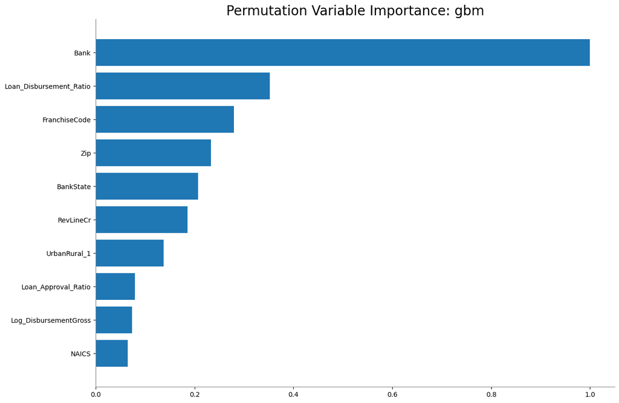

Variable Importances

| Variable | Relative Importance | Scaled Importance | Percentage |
| --- | --- | --- | --- |
| Bank | 0.1095517 | 1.0 | 0.3517880 |
| Loan_Disbursement_Ratio | 0.0385974 | 0.3523215 | 0.1239425 |
| FranchiseCode | 0.0306452 | 0.2797325 | 0.0984065 |
| Zip | 0.0255158 | 0.2329110 | 0.0819353 |
| BankState | 0.0226622 | 0.2068629 | 0.0727719 |
| RevLineCr | 0.0203255 | 0.1855336 | 0.0652685 |
| UrbanRural_1 | 0.0150266 | 0.1371650 | 0.0482530 |
| Loan_Approval_Ratio | 0.0086707 | 0.0791469 | 0.0278429 |
| Log_DisbursementGross | 0.0080504 | 0.0734846 | 0.0258510 |
| NAICS | 0.0070532 | 0.0643822 | 0.0226489 |
| --- | --- | --- | --- |
| DisbursementGross GrAppv SBA_Appv | 0.0000639 | 0.0005834 | 0.0002052 |
| DisbursementGross BalanceGross SBA_Appv | 0.0000490 | 0.0004473 | 0.0001573 |
| DisbursementGross SBA_Appv | 0.0000355 | 0.0003241 | 0.0001140 |
| BalanceGross SBA_Appv | 0.0000234 | 0.0002135 | 0.0000751 |
| DisbursementGross BalanceGross | 0.0000176 | 0.0001607 | 0.0000565 |
| DisbursementGross BalanceGross GrAppv | 0.0000069 | 0.0000628 | 0.0000221 |
| BalanceGross GrAppv SBA_Appv | 0.0000044 | 0.0000403 | 0.0000142 |
| NewExist_3 | 0.0000044 | 0.0000398 | 0.0000140 |
| BalanceGross | 0.0 | 0.0 | 0.0 |
| LowDoc_2 | 0.0 | 0.0 | 0.0 |

```
[37 rows x 4 columns]
```

```python
best_gbm.permutation_importance_plot(test)
```

From the results, we can see that the "Bank" feature has the highest importance, followed by "Loan_Disbursement_Ratio" ,"FranchiseCode", and "Zip".

#### 8.2 Summary plot with Shapley values

```
<h2o.plot._plot_result._MObject at 0x1ddf2f01670>
```

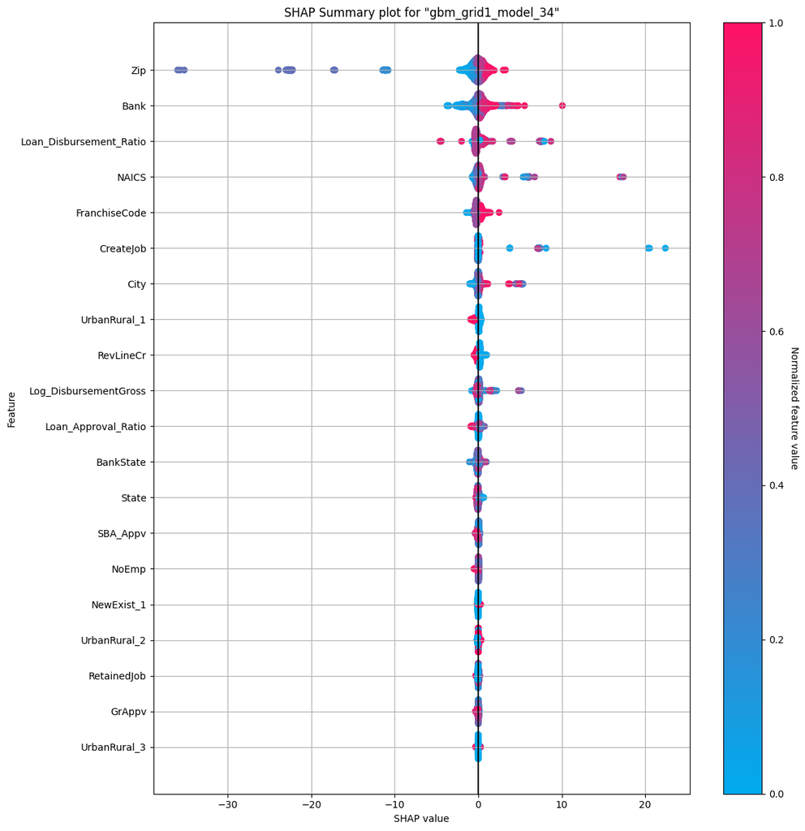

```python
best_gbm.shap_summary_plot(test)
```

From the results, we can see that the "Zip" feature has the highest importance, followed by "Bank" and then "Loan_Disbursement_Ratio".

#### 8.3 Individual observations analysis using Shapley values. Two records for each of the scenarios with significant probability:

```python
best_threshold = best_gbm.find_threshold_by_max_metric(metric='F1')
print("Threshold for Best F1: ",round(best_threshold,2))

probabilities = best_gbm.predict(test)
```

```
Threshold for Best F1:  0.32
gbm prediction progress: |███████████████████████████████████████████████████████| (done) 100%
```

```python
red_np = np.where(probabilities["p0"] > best_threshold, 0, 1)
```

```python
output = test.as_data_frame()
output ['actual_label'] = test['MIS_Status'].as_data_frame()
output['predicted_label'] = (probabilities['p0'] < best_threshold).as_data_frame()
output['predicted_probability'] = probabilities['p0'].as_data_frame()
output = output.sort_values('predicted_probability',ascending=False)
```

```python
output
```

|  | City | State | Zip | Bank | BankState | FranchiseCode | NAICS | NewExist_1 | NewExist_2 | NewExist_3 | ... | BalanceGross SBA_Appv | GrAppv SBA_Appv | DisbursementGross BalanceGross GrAppv | DisbursementGross BalanceGross SBA_Appv | DisbursementGross GrAppv SBA_Appv | BalanceGross GrAppv SBA_Appv | MIS_Status | actual_label | predicted_label | predicted_probability |
| --- | --- | --- | --- | --- | --- | --- | --- | --- | --- | --- | --- | --- | --- | --- | --- | --- | --- | --- | --- | --- | --- |
| 72394 | 0.713489 | 0.281735 | -2.390877 | -5.447234 | 0.383199 | -0.547408 | -0.352792 | 0 | 1 | 0 | ... | -0.004988 | 4.077445 | -0.006093 | -0.008024 | 6.558758 | -0.008777 | 0 | 0 | 0 | 0.999092 |
| 80436 | 0.087599 | 0.281735 | -1.266947 | -4.395729 | 0.383199 | -0.547408 | 0.186703 | 0 | 1 | 0 | ... | -0.002356 | 0.827668 | -0.001066 | -0.001542 | 0.541805 | -0.001782 | 0 | 0 | 0 | 0.999089 |
| 36742 | -0.115199 | -0.315573 | -1.505358 | -3.777171 | -1.142633 | -0.547408 | 0.183499 | 0 | 0 | 1 | ... | -0.001000 | 0.111097 | -0.000084 | -0.000163 | 0.018118 | -0.000239 | 0 | 0 | 0 | 0.999048 |
| 55284 | 0.713489 | 0.281735 | -1.920873 | -5.447234 | 0.383199 | -0.547408 | 0.183499 | 0 | 1 | 0 | ... | -0.000236 | -0.005687 | -0.000024 | 0.000050 | 0.001205 | 0.000012 | 0 | 0 | 0 | 0.999046 |
| 6829 | -0.319850 | -0.284065 | -2.103195 | -2.103195 | -0.634781 | -0.547408 | -0.822224 | 0 | 1 | 0 | ... | -0.000317 | -0.003117 | -0.000004 | 0.000027 | 0.000263 | 0.000007 | 0 | 0 | 0 | 0.999019 |
| ... | ... | ... | ... | ... | ... | ... | ... | ... | ... | ... | ... | ... | ... | ... | ... | ... | ... | ... | ... | ... | ... |
| 10921 | 2.838448 | 0.042298 | 0.142232 | -0.419649 | -0.005733 | 1.010321 | 0.572721 | 0 | 1 | 0 | ... | 0.001055 | 0.243085 | -0.000429 | -0.000424 | -0.097717 | -0.000523 | 1 | 1 | 1 | 0.010171 |
| 37625 | 2.396615 | 0.281735 | 2.396615 | 1.159072 | 1.108251 | 0.604971 | 0.130594 | 1 | 0 | 0 | ... | 0.001055 | 0.243085 | -0.000572 | -0.000565 | -0.130288 | -0.000523 | 1 | 1 | 1 | 0.008229 |
| 43567 | 2.684297 | 0.040033 | 2.684297 | 2.293768 | 0.383199 | 0.604971 | 0.130594 | 0 | 1 | 0 | ... | 0.001116 | 0.292022 | -0.000727 | -0.000669 | -0.175123 | -0.000629 | 1 | 1 | 1 | 0.005357 |
| 51432 | 2.396615 | -0.496751 | 2.396615 | 2.079642 | 0.383199 | 0.604971 | 0.183499 | 0 | 1 | 0 | ... | 0.001138 | 0.302667 | -0.000750 | -0.000693 | -0.184262 | -0.000652 | 0 | 0 | 1 | 0.005256 |
| 26581 | 2.396615 | -0.496751 | 2.396615 | 2.079642 | 0.383199 | 0.604971 | 0.189689 | 0 | 1 | 0 | ... | 0.001052 | 0.261227 | -0.000658 | -0.000602 | -0.149523 | -0.000562 | 1 | 1 | 1 | 0.004528 |

82524 rows × 41 columns

##### Label 0 is correctly identified

```python
label_0_identified_correctly = output[(output['MIS_Status'] == 0 ) & (output['predicted_label'] == 0)].iloc[0:2,:-3]
label_0_identified_correctly = h2o.H2OFrame(label_0_identified_correctly)
```

```
Parse progress: |████████████████████████████████████████████████████████████████| (done) 100%
```

SHAP Explanation

> SHAP explanation shows contribution of features for a given instance. The sum of the feature contributions and the bias term is equal to the raw prediction of the model, i.e., prediction before applying inverse link function. H2O implements TreeSHAP which when the features are correlated, can increase contribution of a feature that had no influence on the prediction.

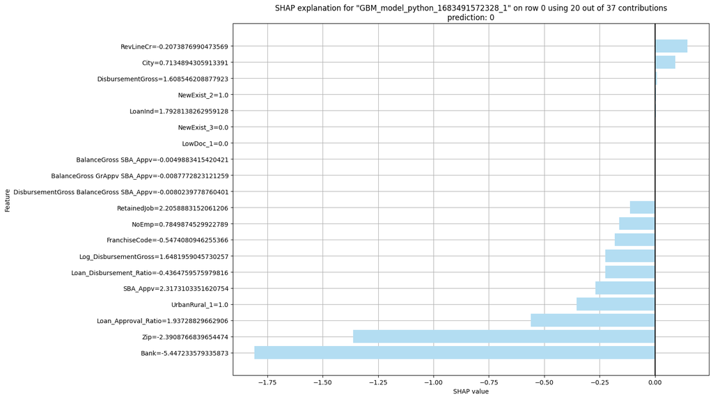

SHAP Explanation

> SHAP explanation shows contribution of features for a given instance. The sum of the feature contributions and the bias term is equal to the raw prediction of the model, i.e., prediction before applying inverse link function. H2O implements TreeSHAP which when the features are correlated, can increase contribution of a feature that had no influence on the prediction.

```
<h2o.plot._plot_result._MObject at 0x1ddf26d68b0>
```

```python
row_index = 0
gbm_model.explain_row(label_0_identified_correctly, row_index =row_index,include_explanations='shap_explain_row')
```

###### The most influential feature on the response variable is Bank , which has a negative impact followed by Zip with negative effect

SHAP Explanation

> SHAP explanation shows contribution of features for a given instance. The sum of the feature contributions and the bias term is equal to the raw prediction of the model, i.e., prediction before applying inverse link function. H2O implements TreeSHAP which when the features are correlated, can increase contribution of a feature that had no influence on the prediction.

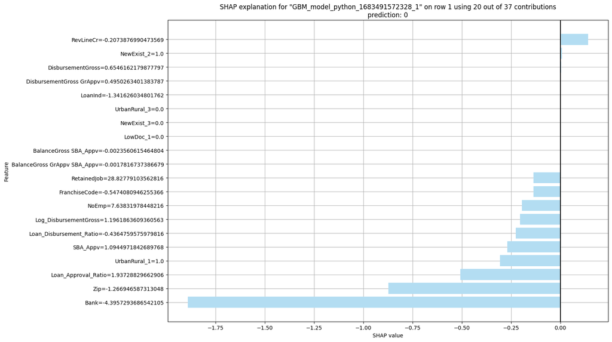

SHAP Explanation

> SHAP explanation shows contribution of features for a given instance. The sum of the feature contributions and the bias term is equal to the raw prediction of the model, i.e., prediction before applying inverse link function. H2O implements TreeSHAP which when the features are correlated, can increase contribution of a feature that had no influence on the prediction.

```
<h2o.plot._plot_result._MObject at 0x1ddf25f33a0>
```

```python
row_index = 1
gbm_model.explain_row(label_0_identified_correctly, row_index =row_index,include_explanations='shap_explain_row')
```

###### The most influential feature on the response variable is Bank , which has a negative impact followed byZip with negative effect

##### Label 0 is identified as 1

```python
label_0_identified_as_1 = output[(output['MIS_Status'] == 0 ) & (output['predicted_label'] == 1)].iloc[0:2,:-3]
label_0_identified_as_1 = h2o.H2OFrame(label_0_identified_as_1)
```

```
Parse progress: |████████████████████████████████████████████████████████████████| (done) 100%
```

SHAP Explanation

> SHAP explanation shows contribution of features for a given instance. The sum of the feature contributions and the bias term is equal to the raw prediction of the model, i.e., prediction before applying inverse link function. H2O implements TreeSHAP which when the features are correlated, can increase contribution of a feature that had no influence on the prediction.

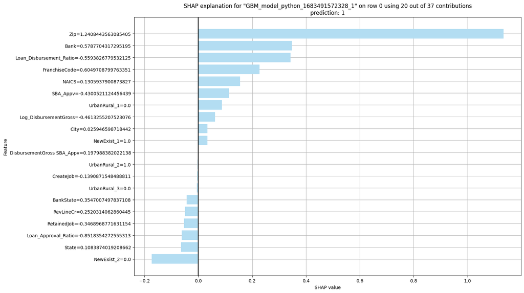

SHAP Explanation

> SHAP explanation shows contribution of features for a given instance. The sum of the feature contributions and the bias term is equal to the raw prediction of the model, i.e., prediction before applying inverse link function. H2O implements TreeSHAP which when the features are correlated, can increase contribution of a feature that had no influence on the prediction.

```
<h2o.plot._plot_result._MObject at 0x1ddf27ed430>
```

```python
row_index = 0
gbm_model.explain_row(label_0_identified_as_1, row_index =row_index,include_explanations='shap_explain_row')
```

SHAP Explanation

> SHAP explanation shows contribution of features for a given instance. The sum of the feature contributions and the bias term is equal to the raw prediction of the model, i.e., prediction before applying inverse link function. H2O implements TreeSHAP which when the features are correlated, can increase contribution of a feature that had no influence on the prediction.

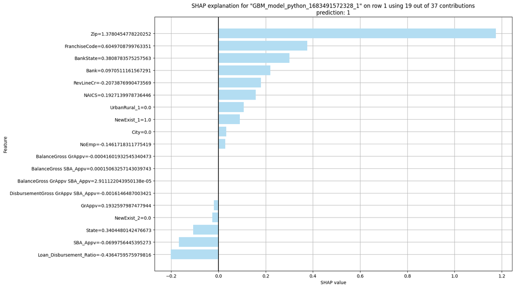

SHAP Explanation

> SHAP explanation shows contribution of features for a given instance. The sum of the feature contributions and the bias term is equal to the raw prediction of the model, i.e., prediction before applying inverse link function. H2O implements TreeSHAP which when the features are correlated, can increase contribution of a feature that had no influence on the prediction.

```
<h2o.plot._plot_result._MObject at 0x1ddf2889fd0>
```

```python
row_index = 1
gbm_model.explain_row(label_0_identified_as_1, row_index =row_index,include_explanations='shap_explain_row')
```

###### The most influential feature on the response variable is Zip , which has a positive impact followed by Franchise Code with positive effect

##### Label 1 is correctly identified

```python
label_1_identified_correctly = output[(output['MIS_Status'] == 1 ) & (output['predicted_label'] == 1)].iloc[0:2,:-3]
label_1_identified_correctly = h2o.H2OFrame(label_1_identified_correctly)
```

```
Parse progress: |████████████████████████████████████████████████████████████████| (done) 100%
```

SHAP Explanation

> SHAP explanation shows contribution of features for a given instance. The sum of the feature contributions and the bias term is equal to the raw prediction of the model, i.e., prediction before applying inverse link function. H2O implements TreeSHAP which when the features are correlated, can increase contribution of a feature that had no influence on the prediction.

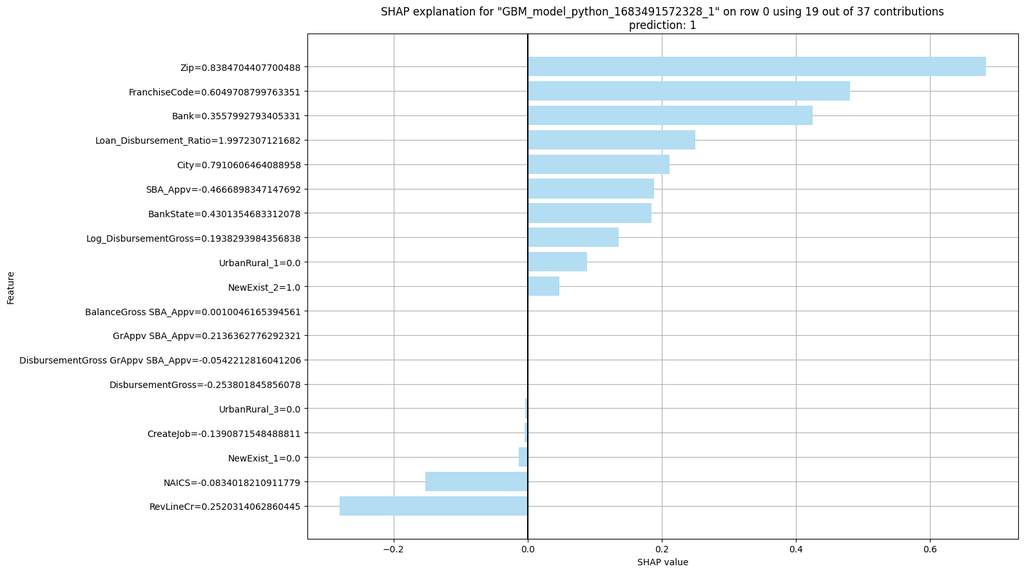

SHAP Explanation

> SHAP explanation shows contribution of features for a given instance. The sum of the feature contributions and the bias term is equal to the raw prediction of the model, i.e., prediction before applying inverse link function. H2O implements TreeSHAP which when the features are correlated, can increase contribution of a feature that had no influence on the prediction.

```
<h2o.plot._plot_result._MObject at 0x1ddf29b9b20>
```

```python
row_index = 0
gbm_model.explain_row(label_1_identified_correctly, row_index =row_index,include_explanations='shap_explain_row')
```

###### The most influential feature on the response variable is Zip , which has a positive impact followed by Franchise Code with positive effect

SHAP Explanation

> SHAP explanation shows contribution of features for a given instance. The sum of the feature contributions and the bias term is equal to the raw prediction of the model, i.e., prediction before applying inverse link function. H2O implements TreeSHAP which when the features are correlated, can increase contribution of a feature that had no influence on the prediction.

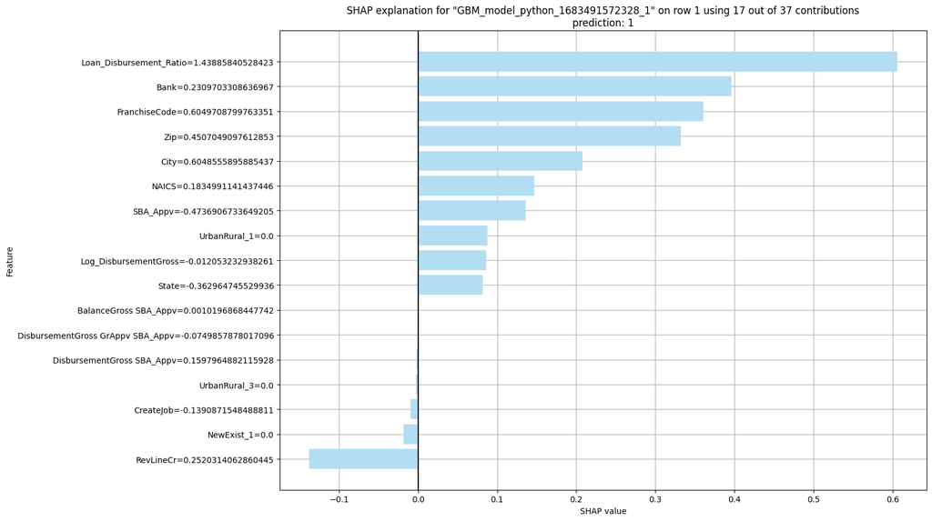

SHAP Explanation

> SHAP explanation shows contribution of features for a given instance. The sum of the feature contributions and the bias term is equal to the raw prediction of the model, i.e., prediction before applying inverse link function. H2O implements TreeSHAP which when the features are correlated, can increase contribution of a feature that had no influence on the prediction.

```
<h2o.plot._plot_result._MObject at 0x1ddf2f96220>
```

```python
row_index = 1
gbm_model.explain_row(label_1_identified_correctly, row_index =row_index,include_explanations='shap_explain_row')
```

###### The most influential feature on the response variable is Loan Disbursement Ratio , which has a positive impact followed by Bank with positive effect

##### Label 1 is identified as 0

```python
label_1_identified_as_0 = output[(output['MIS_Status'] == 1 ) & (output['predicted_label'] == 0)].iloc[0:2,:-3]
label_1_identified_as_0 = h2o.H2OFrame(label_1_identified_as_0)
```

```
Parse progress: |████████████████████████████████████████████████████████████████| (done) 100%
```

SHAP Explanation

> SHAP explanation shows contribution of features for a given instance. The sum of the feature contributions and the bias term is equal to the raw prediction of the model, i.e., prediction before applying inverse link function. H2O implements TreeSHAP which when the features are correlated, can increase contribution of a feature that had no influence on the prediction.

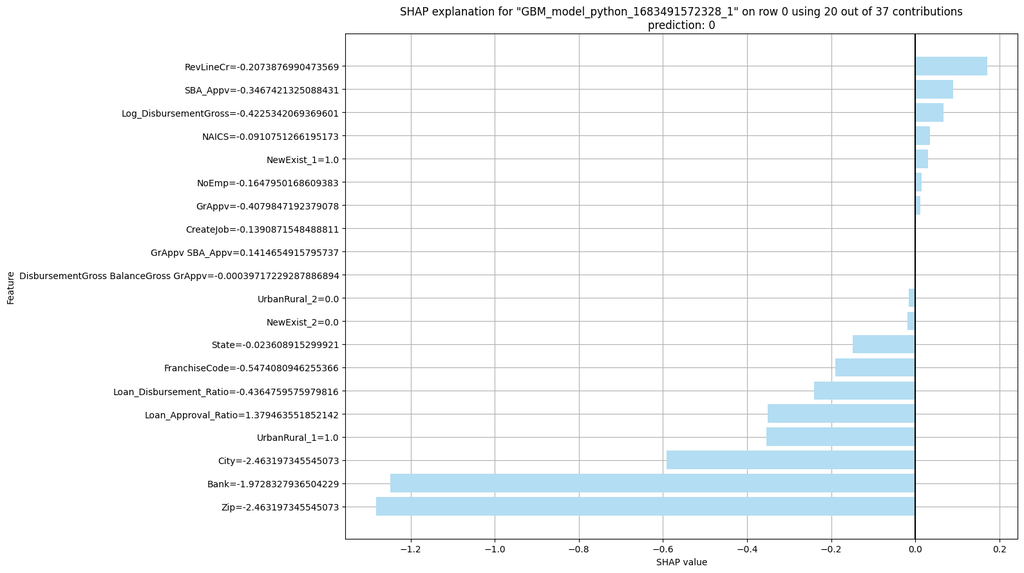

SHAP Explanation

> SHAP explanation shows contribution of features for a given instance. The sum of the feature contributions and the bias term is equal to the raw prediction of the model, i.e., prediction before applying inverse link function. H2O implements TreeSHAP which when the features are correlated, can increase contribution of a feature that had no influence on the prediction.

```
<h2o.plot._plot_result._MObject at 0x1ddf30e9760>
```

```python
row_index = 0
gbm_model.explain_row(label_1_identified_as_0, row_index =row_index,include_explanations='shap_explain_row')
```

SHAP Explanation

> SHAP explanation shows contribution of features for a given instance. The sum of the feature contributions and the bias term is equal to the raw prediction of the model, i.e., prediction before applying inverse link function. H2O implements TreeSHAP which when the features are correlated, can increase contribution of a feature that had no influence on the prediction.

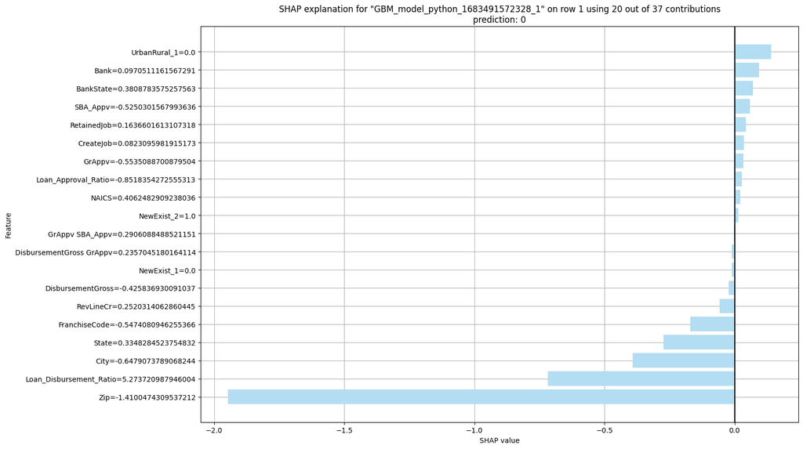

SHAP Explanation

> SHAP explanation shows contribution of features for a given instance. The sum of the feature contributions and the bias term is equal to the raw prediction of the model, i.e., prediction before applying inverse link function. H2O implements TreeSHAP which when the features are correlated, can increase contribution of a feature that had no influence on the prediction.

```
<h2o.plot._plot_result._MObject at 0x1ddf6179820>
```

```python
row_index = 1
gbm_model.explain_row(label_1_identified_as_0, row_index =row_index,include_explanations='shap_explain_row')
```

###### The most influential feature on the response variable is Zip , which has a negative impact followed by Loan Disbursement Ratio with Negative effect